# UnderCount

# Read in the csv and set the seed.

Initially, we need to read in the csv from GitHub, attach the vote data, and set the seed to see the same results each time.

```r
library(ggplot2)
voteData = read.csv('https://raw.githubusercontent.com/jgscott/STA380/master/data/georgia2000.csv')
head(voteData)
```

```
##     county ballots votes   equip poor urban atlanta perAA gore bush
## 1  APPLING    6617  6099   LEVER    1     0       0 0.182 2093 3940
## 2 ATKINSON    2149  2071   LEVER    1     0       0 0.230  821 1228
## 3    BACON    3347  2995   LEVER    1     0       0 0.131  956 2010
## 4    BAKER    1607  1519 OPTICAL    1     0       0 0.476  893  615
## 5  BALDWIN   12785 12126   LEVER    0     0       0 0.359 5893 6041
## 6    BANKS    4773  4533   LEVER    0     0       0 0.024 1220 3202
```

```r
attach(voteData)
set.seed(78705)
```

# Create a new column that represents the UnderCount

Right now, we just have the amount of ballots cast and the amount of votes recorded. We want to create a new variable called UnderCount, which will represent the difference between those two variables.

```r
voteData$UnderCount <-  voteData$ballots - voteData$votes
```

# Factorize the data

Since the variables “poor”, “atlanta”, and “urban” are represented as numeric values, we want to factorize these such that these variables are no longer numeric. This will allow us to create better looking graphs using those variables.

```r
voteData$poor = as.factor(voteData$poor)
voteData$atlanta = as.factor(voteData$atlanta)
voteData$urban = as.factor(voteData$urban)
```

# Create a new column that represents the percentage of the UnderCount

While the amount of votes that each county UnderCount is useful, we want to convert this number into a percentage of the total ballots cast, so that larger counties can be compared to smaller counties more accurately.

```r
voteData$UnderCountPercent <- voteData$UnderCount / voteData$ballots
```

# Show the summary of the voteData

Next, we show the initial summary of the voteData, which tells us some interesting information about each variable in the data set. However, it is hard to visualize all of this, and these numbers do not mean much without comparing variables with each other.

```r
summary(voteData)
```

```
##       county       ballots           votes            equip    poor
##  APPLING :  1   Min.   :   881   Min.   :   832   LEVER  :74   0:87
##  ATKINSON:  1   1st Qu.:  3694   1st Qu.:  3506   OPTICAL:66   1:72
##  BACON   :  1   Median :  6712   Median :  6299   PAPER  : 2
##  BAKER   :  1   Mean   : 16927   Mean   : 16331   PUNCH  :17
##  BALDWIN :  1   3rd Qu.: 12251   3rd Qu.: 11846
##  BANKS   :  1   Max.   :280975   Max.   :263211
##  (Other) :153
##  urban   atlanta     perAA             gore             bush
##  0:117   0:144   Min.   :0.0000   Min.   :   249   Min.   :   271
##  1: 42   1: 15   1st Qu.:0.1115   1st Qu.:  1386   1st Qu.:  1804
##                  Median :0.2330   Median :  2326   Median :  3597
##                  Mean   :0.2430   Mean   :  7020   Mean   :  8929
##                  3rd Qu.:0.3480   3rd Qu.:  4430   3rd Qu.:  7468
##                  Max.   :0.7650   Max.   :154509   Max.   :140494
##
##    UnderCount      UnderCountPercent
##  Min.   :    0.0   Min.   :0.00000
##  1st Qu.:  152.5   1st Qu.:0.02779
##  Median :  296.0   Median :0.03983
##  Mean   :  595.5   Mean   :0.04379
##  3rd Qu.:  523.5   3rd Qu.:0.05647
##  Max.   :17764.0   Max.   :0.18812
##
```

# Create a Box Plot using UnderCountPercent and equipment type

First, we create a box plot using UnderCountPercent as the Y variable and equipment type as the X variable. This shows us that equipment type alone does not seem to be a major factor in determining UnderCountPercent, as each equipment type seems to have about the same UnderCountPercent, though some have a higher variance than others.

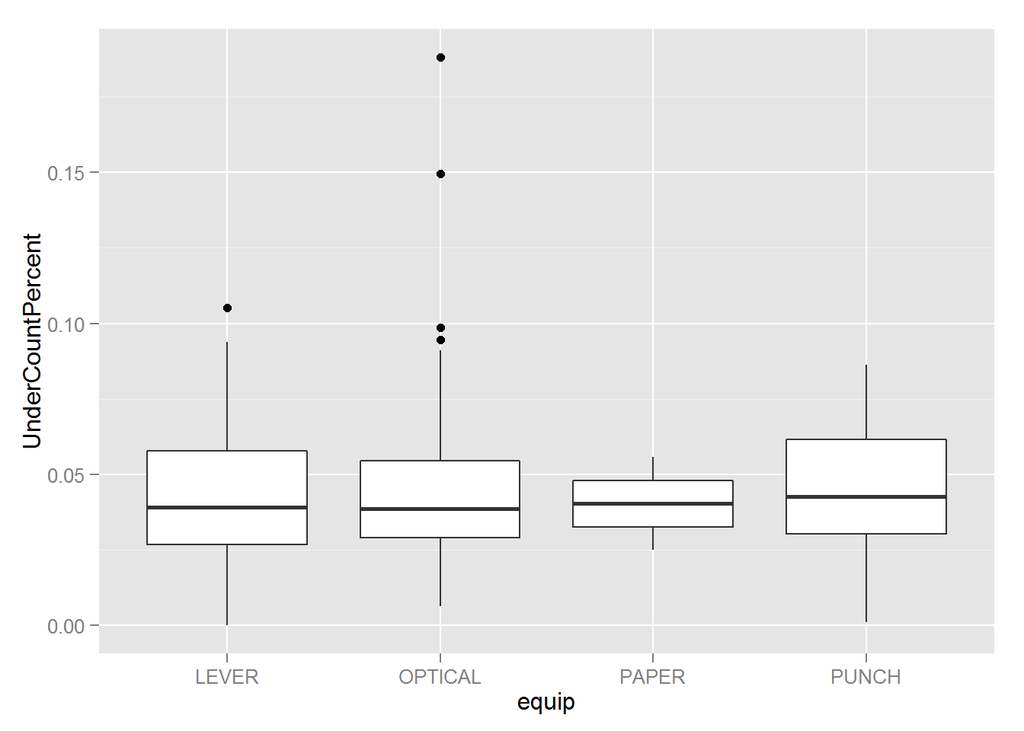

```r
ggplot(voteData, aes(equip, UnderCountPercent)) + geom_boxplot()
```

# Create a Box Plot using UnderCountPercent, equipment type, and seperate based on if the county is poor or not.

Next, we create a box plot using UnderCountPercent as the Y variable, and Equipment type as the X variable. We also seperate the data points based on whether or not the county is poor or not, with red representing that the county is not poor, and blue represeting that the county is poor.

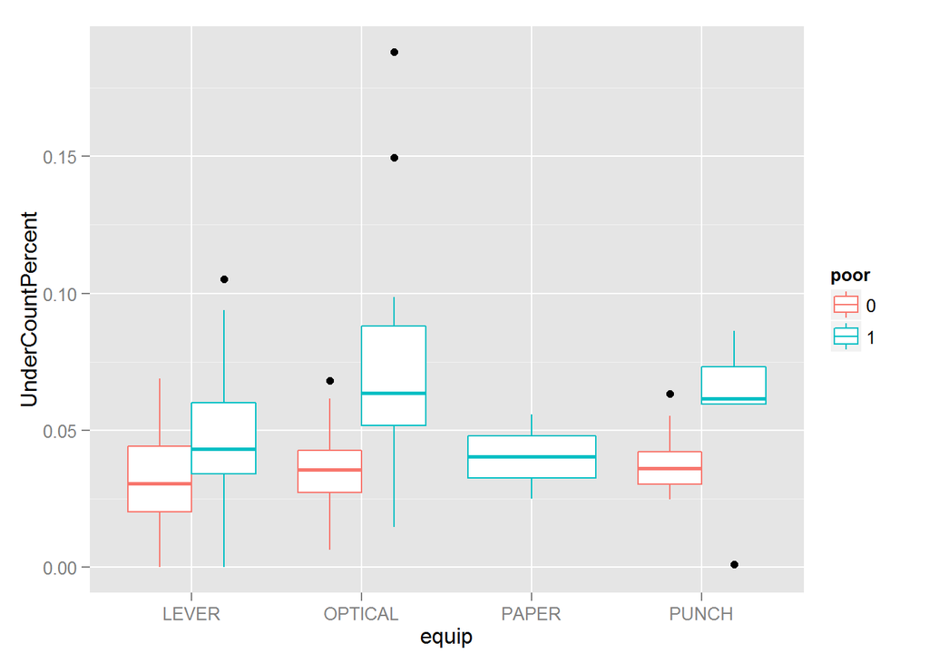

```r
ggplot(voteData, aes(equip, UnderCountPercent, col = poor)) + geom_boxplot()
```

This box plot shows much more interesting results, as it shows that poorer counties are much more likely to have a higher Under Count Percentage than counties that are not poor are. It also shows that only poor counties seem to use Paper equipment, though interestingly enough, Paper seems to have a lower UnderCountPercent than the other types of equipment among poor counties.

# Create a Box Plot using UnderCountPercent, equipment type, and seperate based on if the environment is urban or not.

Next, we create a Box Plot using UnderCountPercent as the Y variable and Equipment type as the X variable, with red representing a non-urban county, and blue representing an urban county.

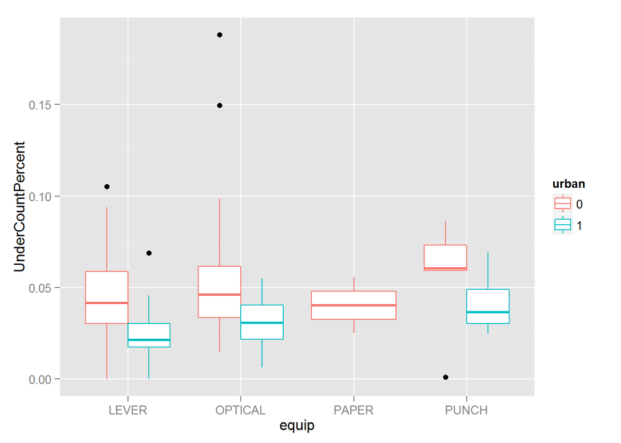

```r
ggplot(voteData, aes(equip, UnderCountPercent, col = urban)) + geom_boxplot()
```

Once again, we can see a clear pattern in the UnderCountPercent. Counties that are not Urban seem to have a much higher UnderCountPercent than counties that are urban. This likely means that there are some differences between an urban and non urban enviornment that rather drastically change the chance that a vote will be Under Counted.

# Create a Box Plot using UnderCountPercent, and atlanta

Next, we create another box plot with UnderCountPercent as the Y variable and whether a county is in atlanta or not as the X variable.

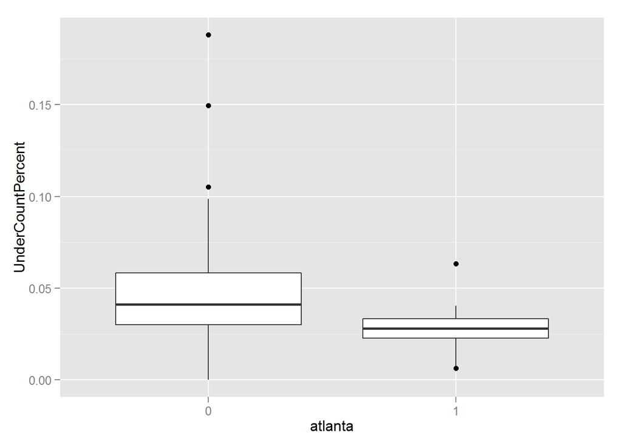

```r
ggplot(voteData, aes(atlanta, UnderCountPercent)) + geom_boxplot()
```

# Create a Scatter Plot using UnderCountPercent and perAA

Finally, we create a Scatter Plot using UnderCountPercent as the Y variable and percentage of African Americans as the X variable.

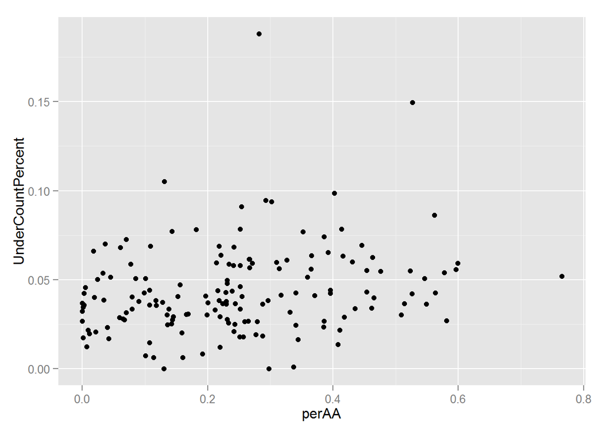

```r
ggplot(voteData, aes(perAA, UnderCountPercent)) + geom_point()
```

Unlike the other graphs, there is not distinctive pattern in the graph between UnderCountPercent and percentage of African Americans. This suggests that the amount of African Amercians in a county has little to no significance in determining how many votes are Under Counted in a county.